# ThetaMater: Rapid and scalable Bayesian estimation of theta from genomic data

## Step 4.1: `ThetaMater.M1`: function to simulate a posterior distribution of theta without among-locus rate variation

Here we will estimate Theta for the given dataset using ThetaMater.M1. The input arguments for the function `ThetaMater.M1` are as follows:

`ThetaMater.M1(k.vec, l.vec, n.vec, c.vec, ngens, burnin, thin, theta.shape, theta.scale)`  
* `k.vec`: vector of mutation counts  
* `l.vec`: vector of locus lengths  
* `n.vec`: vector of sample counts  
* `c.vec`: vector of unique pattern counts  
* `ngens`: number of iterations to run the MCMC simulation  
* `burnin`: number of iterations to discard as burnin  
* `thin`: number of iterations between recorded MCMC samples  
* `theta.shape`: shape parameter of the prior gamma distribution on theta (See Step 2)  
* `theta.scale`: scale parameter of the prior gamma distribution on theta (See Step 2)

Before estimating $\theta$ with ThetaMater.M1, let’s first view and set the prior distribution for $\theta$ that we will use in this example analysis. These data were simulated using theta = 0.002, and thus we set a prior distribution with an expectation of 0.002 for this example population. For empirical analyses, the values of these parameters (theta.shape, theta.scale) will be ideally set to reflect prior knowledge about a given population under study. For this analysis will set `theta.shape` and `theta.scale` as the following:

```r
shape = 2
scale = 0.001
E.theta = shape*scale
E.theta
```

```
## [1] 0.002
```

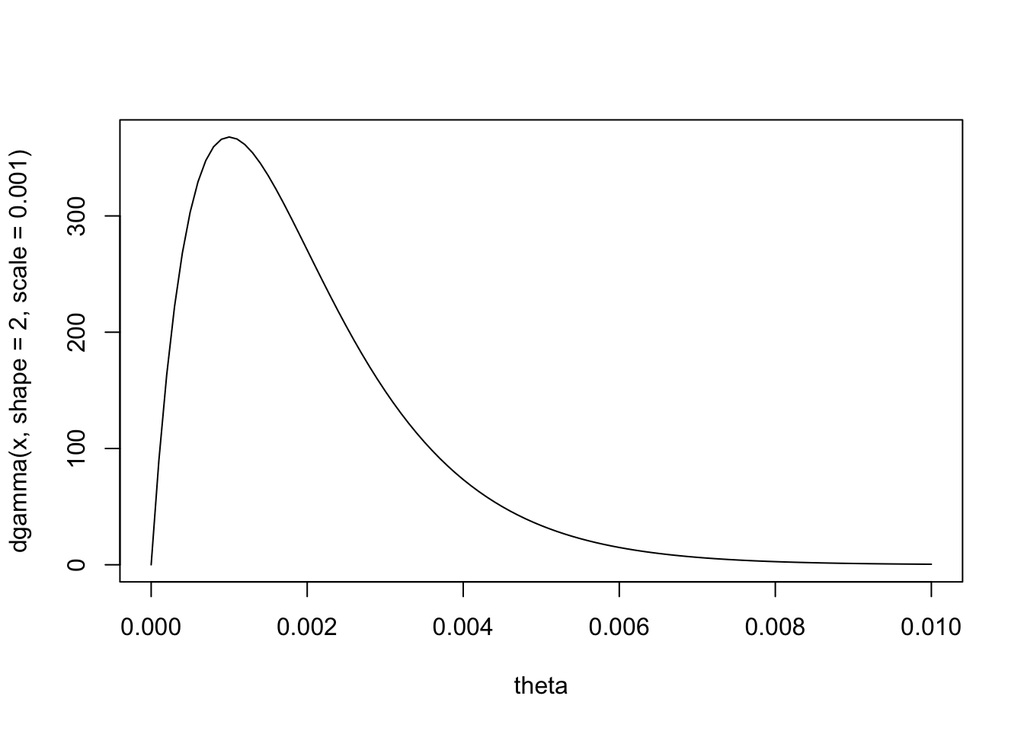

```r
curve( dgamma(x,shape = 2,scale = 0.001), xlim=c(0,.01), xlab = "theta")
```

Now we are ready to estimate $\theta$ We can load the example data and run the MCMC for ThetaMater.M1 using the code below:

```r
data(example.dat,package= "ThetaMater")

example.MCMC <- ThetaMater.M1(k.vec = example.dat$k.vec, l.vec = example.dat$l.vec, n.vec = example.dat$n.vec, c.vec = example.dat$c.vec, ngens = 50, burnin = 1, theta.shape = shape, theta.scale = scale, thin = 2)
```

```
## MCMCmetrop1R iteration 1 of 51
## function value = -878.72859
## theta =
##    0.00188
## Metropolis acceptance rate = 1.00000
##
##
##
## @@@@@@@@@@@@@@@@@@@@@@@@@@@@@@@@@@@@@@@@@@@@@@@@@@@@@@@@@
## The Metropolis acceptance rate was 0.78431
## @@@@@@@@@@@@@@@@@@@@@@@@@@@@@@@@@@@@@@@@@@@@@@@@@@@@@@@@@
```

We didn’t run the mcmc very long, and thus the MCMC output does not appear at stationarity. See trace and density plot of the posterior below:

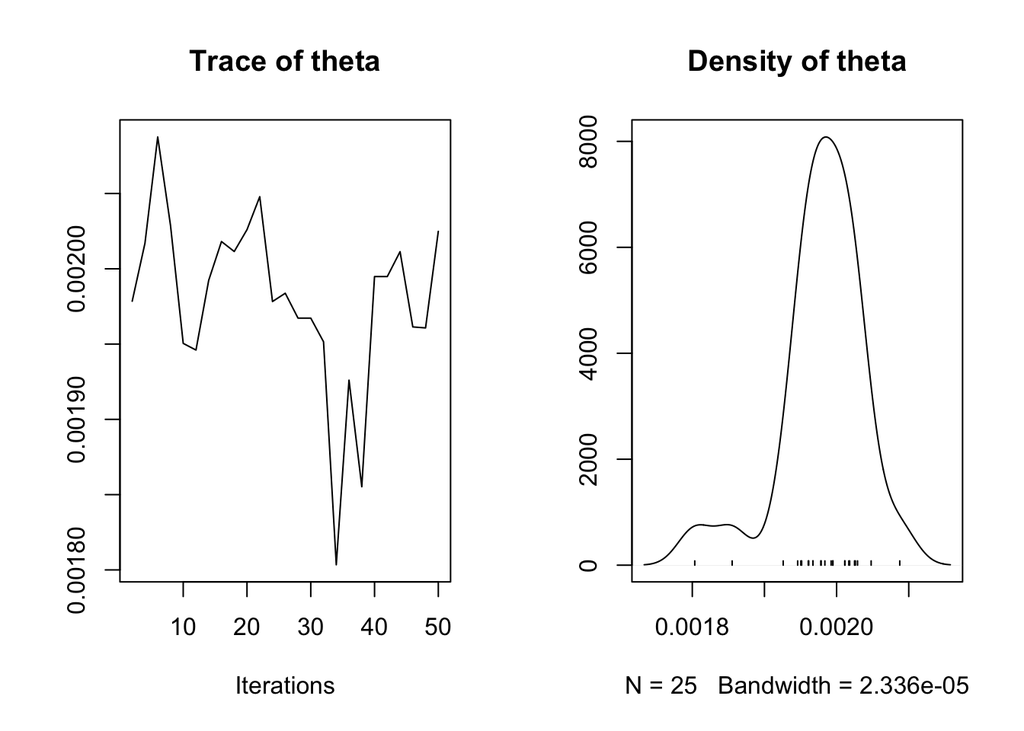

```r
varnames(example.MCMC) <- "theta"
plot(example.MCMC)
```

Let’s look at the results from a much longer run that was executed using the below command:

```r
example.MCMC <- ThetaMater.M1(k.vec = example.dat$k.vec, l.vec = example.dat$l.vec, n.vec = example.dat$n.vec, c.vec = example.dat$c.vec,ngens = 1000000, burnin = 1000, thin = 10, theta.shape = shape, theta.scale = scale)
```

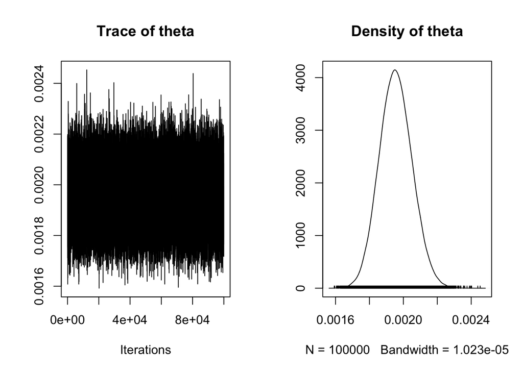

```r
file.loc <- system.file("example.MCMC.M1.csv", package="ThetaMater")
plot(as.mcmc(read.csv(file = file.loc)))
```

As you can see from the trace and density plot, the MCMC has reached stationarity (represented by the classic “fuzzy caterpillar” shape). Also, we can look at the mean and variance of the posterior distribution of $\theta$ using this code below:

```r
file.loc <- system.file("example.MCMC.M1.csv", package="ThetaMater")
mean(as.mcmc(read.csv(file = file.loc))) # close to the simulated value of 0.002
```

```
## [1] 0.00195588
```

```r
sd(as.mcmc(read.csv(file = file.loc)))
```

```
## [1] 9.646917e-05
```

```r
summary(as.mcmc(read.csv(file = file.loc)))
```

```
##
## Iterations = 1:1e+05
## Thinning interval = 1
## Number of chains = 1
## Sample size per chain = 1e+05
##
## 1. Empirical mean and standard deviation for each variable,
##    plus standard error of the mean:
##
##           Mean             SD       Naive SE Time-series SE
##      1.956e-03      9.647e-05      3.051e-07      4.375e-07
##
## 2. Quantiles for each variable:
##
##     2.5%      25%      50%      75%    97.5%
## 0.001772 0.001890 0.001954 0.002020 0.002150
```

*IMPORTANT: Don’t panic if you see this error when running ThetaMater: “initial value in ‘vmmin’ is not finite”. This just means that the likelihood of the data is very small under the current prior settings and thus ‘infinite’ likelihood values may arise. Thus, the likelihood function used by ThetaMater may react poorly to badly specified prior values for $\theta$. If you see this error when running ThetaMater, try different prior settings and multiple runs. See below commands for a demonstration. As always, contact the author (radams@uta.edu) if you need further guidance with setting priors for your dataset.*

```r
# Here's a poorly specified prior that is far from the true value (this will give the error)
example.MCMC <- ThetaMater.M1(k.vec = example.dat$k.vec, l.vec = example.dat$l.vec, n.vec = example.dat$n.vec, c.vec = example.dat$c.vec,ngens = 500, burnin = 1, thin = 1, theta.shape = 10, theta.scale = 10)
```

```
## Error in optim(theta.init.0, maxfun, control = optim.control, lower = optim.lower, : initial value in 'vmmin' is not finite
```

```r
# Let's try another prior setting that is closer to the true value of theta
example.MCMC <- ThetaMater.M1(k.vec = example.dat$k.vec, l.vec = example.dat$l.vec, n.vec = example.dat$n.vec, c.vec = example.dat$c.vec,ngens = 500, burnin = 1, thin = 1, theta.shape = 1, theta.scale = 1)
```

```
## MCMCmetrop1R iteration 1 of 501
## function value = -15914.27336
## theta =
##    0.70288
## Metropolis acceptance rate = 1.00000
##
## MCMCmetrop1R iteration 501 of 501
## function value = -15884.57594
## theta =
##    0.69850
## Metropolis acceptance rate = 0.84032
##
##
##
## @@@@@@@@@@@@@@@@@@@@@@@@@@@@@@@@@@@@@@@@@@@@@@@@@@@@@@@@@
## The Metropolis acceptance rate was 0.84032
## @@@@@@@@@@@@@@@@@@@@@@@@@@@@@@@@@@@@@@@@@@@@@@@@@@@@@@@@@
```

It works! No error this time. With better prior settings that are close to the true value, this likelihood function will not misbehave and the error will not occur. As always, contact the author Rich Adams (radams@uta.edu) if you have any questions and/or receive this error message.

## Step 4.2: `ThetaMater.M2`: function to simulate a posterior distribution of $\theta$ with a fixed shape parameter $\alpha$ of among-locus rate variation

Here we will estimate the posterior distribution of $\theta$ using a fixed $\alpha$ parameter describing the distribution of among-locus rate variation within our dataset. The input arguments for the function `ThetaMater.M2` are as follows:

`ThetaMater.M2(k.vec, l.vec, n.vec, c.vec, alpha, K.classes, ngens, burnin, thin, theta.shape, theta.scale)` * `k.vec`: vector of mutation counts  
* `l.vec`: vector of locus lengths  
* `n.vec`: vector of sample counts  
* `c.vec`: vector of unique pattern counts  
* `ngens`: number of generations to run the MCMC simulation  
* `alpha`: fixed alpha parameter describing the shape of the distribution of among-locus rate variation  
* `K.classes`: number of disctinct classes to approximate the gamma distribution (4-20 are commonly used for datasets) * `burnin`: number of generations to discard as burnin  
* `thin`: number of generations between recorded MCMC samples  
* `theta.shape`: shape parameter of the prior gamma distribution on $\theta$ (See Step 2)  
* `theta.scale`: scale parameter of the prior gamma distribution on $\theta$ (See Step 2)

The following example data were simulated using $\theta$ = 0.002 and $\alpha$ = 0.1 (using 4 rate classes to approximate the gamma distribution)

```r
data(example.M2.dat, package= "ThetaMater")
# Let's look at the data
example.M2.dat$k.vec # mutation counts
example.M2.dat$l.vec # locus lengths
example.M2.dat$n.vec # number of samples
example.M2.dat$c.vec # number of observations
```

Failure to account for among-locus rate variation can affect parameter estimates, such as $\theta$. So, let’s see what happens when we do not account for among-locus rate variation (i.e., model misspecification). Here the data were generated under ThetaMater.M2, but we will first simulate posterior distributions of $\theta$ using ThetaMater.M1, which does not account for rate variation.

```r
shape = 2
scale = 0.001

example.MCMC.M1.M2 <- ThetaMater.M1(k.vec = example.M2.data$k.vec, l.vec = example.M2.data$l.vec, n.vec = example.M2.data$n.vec, c.vec = example.M2.data$c.vec, theta.shape = shape, theta.scale = scale, ngens = 1000000, burnin = 100000, thin = 100)
```

The results from this ‘model-misspecification’ analysis are shown below:

```r
data(example.MCMC.M2,package= "ThetaMater")
mean(example.MCMC.M2)
```

```
## [1] 0.001560757
```

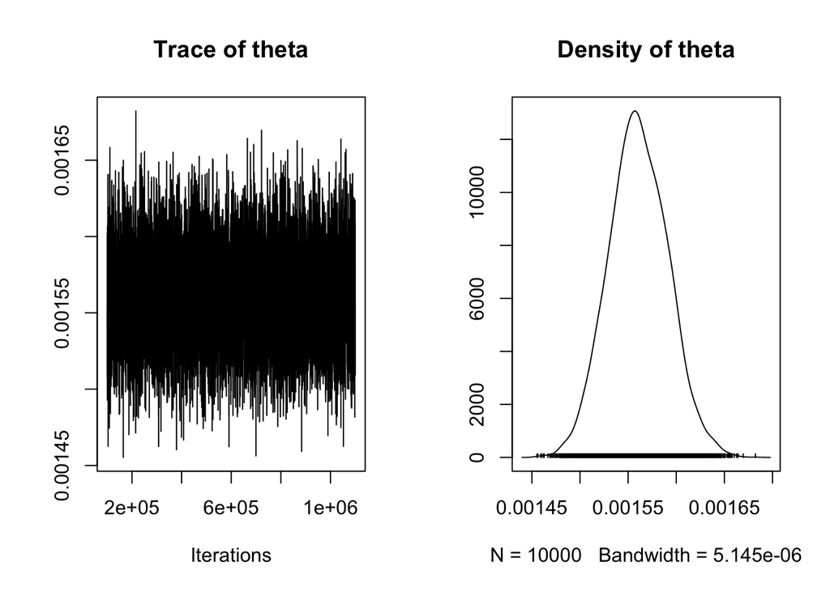

```r
varnames(example.MCMC.M2) <- "theta"
plot(as.mcmc(example.MCMC.M2))
```

In the above case, using `ThetaMater.M1` instead of the correct `ThetaMater.M2` (or `ThetaMater.M3`, see below) function lead to substantially lower estimates $\theta$ of with a posterior distribution that is tightly peaked at $\theta$ = 0.0015. So, let’s use `ThetaMater.M2` to infer the posterior distribution of $\theta$ given $\alpha$ = 0.10 and k = 4.

```r
shape = 2
scale = 0.001

example.MCMC.M2 <- ThetaMater.M2(k.vec = example.M2.data$k.vec, l.vec = example.M2.data$l.vec, n.vec = example.M2.data$n.vec, c.vec = example.M2.data$c.vec, theta.shape = shape, theta.scale = scale, ngens = 1000000, burnin = 100000, thin = 100, K = 4, alpha.param = 0.1)
```

And here are the results from this analysis:

```r
data(example.MCMC.M2.M2,package= "ThetaMater")
mean(example.MCMC.M2.M2)
```

```
## [1] 0.002096711
```

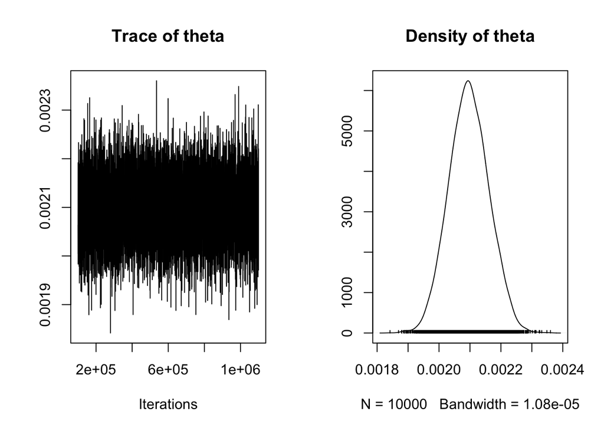

```r
varnames(example.MCMC.M2.M2) <- "theta"
plot(as.mcmc(example.MCMC.M2.M2))
```

## Step 4.3: `ThetaMater.M3`: function to simulate a posterior distribution of $\theta$ and $\alpha$

Here we use `ThetaMater.M3` to estimate the joint posterior distribution of $\theta$ and $\alpha$ for our dataset. The input arguments for the function `ThetaMater.M3` are as follows:

`ThetaMater.M3(k.vec, l.vec, n.vec, c.vec, alpha, K.classes, ngens, burnin, thin, theta.shape, theta.scale, alpha.shape, alpha.scale)`  
* `k.vec`: vector of mutation counts  
* `l.vec`: vector of locus lengths  
* `n.vec`: vector of sample counts  
* `c.vec`: vector of unique pattern counts  
* `ngens`: number of generations to run the MCMC simulation  
* `K.classes`: number of diiscrete classes to approximate the gamma distribution (4-20 are commonly used)  
* `burnin`: number of generations to discard as burnin  
* `thin`: number of generations between recorded MCMC samples  
* `theta.shape`: shape parameter of the prior gamma distribution on $\theta$ (See Step 2)  
* `theta.scale`: scale parameter of the prior gamma distribution on $\theta$ (See Step 2)  
* `alpha.shape`: shape parameter of the prior gamma distribution on $\alpha$ (See Step 2)  
* `alpha.scale`: scale parameter of the prior gamma distribution on $\alpha$ (See Step 2)

Notice: here we will set the prior distributions for both $\theta$ and $\alpha$ (theta.shape, theta.scale, alpha.shape, alpha.scale). Let’s load the data from the previous analyses (Step 4.2, M2)

```r
data(example.M2.dat, package= "ThetaMater")
# Let's look at the data
example.M2.dat$k.vec # mutation counts
example.M2.dat$l.vec # locus lengths
example.M2.dat$n.vec # number of samples
example.M2.dat$c.vec # number of observations
```

Let’s run these analysis using the command below:

```r
example.MCMC.M3 <- ThetaMater.M3(k.vec = example.M2.dat$k.vec, l.vec = example.M2.dat$l.vec, n.vec = example.M2.dat$n.vec, c.vec = example.M2.dat$c.vec, K = 4, ngens = 1000000, burnin = 100000, thin = 10, theta.shape = theta.shape, theta.scale = theta.scale, alpha.shape = alpha.shape, alpha.scale = alpha.scale)
```

And here are the results from this run, with the posterior of $\theta$ on top and $\alpha$ on bottom

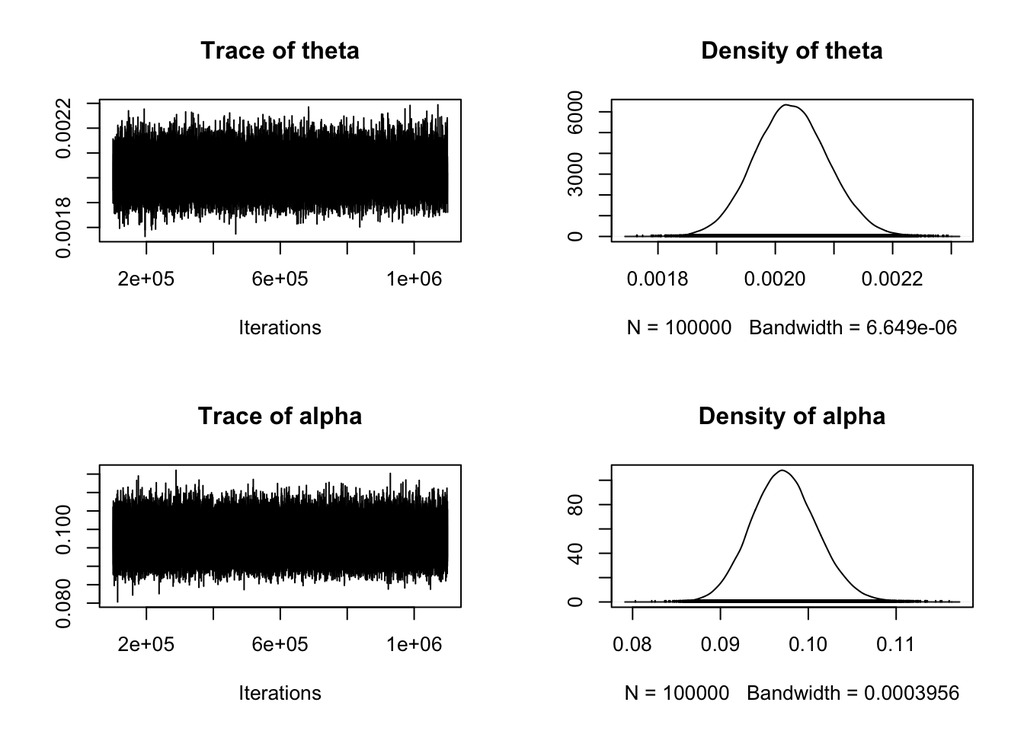

```r
data(example.MCMC.M3,package= "ThetaMater")
varnames(example.MCMC.M3) <- c("theta", "alpha")
plot(as.mcmc(example.MCMC.M3))
```

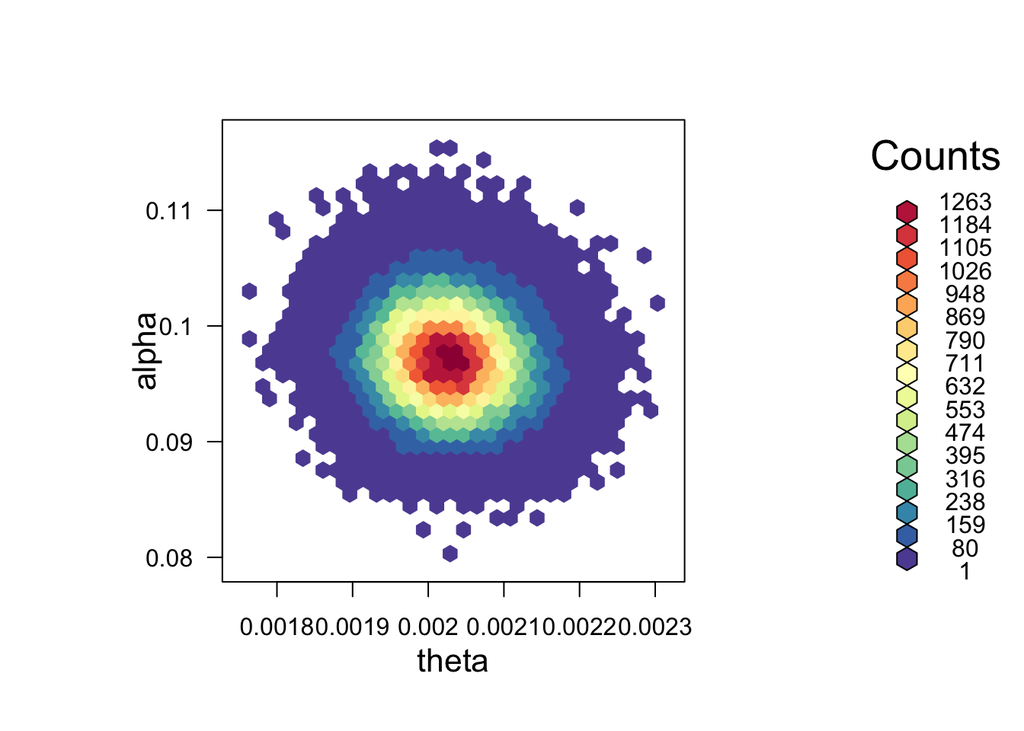

```r
# See instructions at http://www.everydayanalytics.ca/2014/09/5-ways-to-do-2d-histograms-in-r.html
library(hexbin)
library(RColorBrewer)
rf <- colorRampPalette(rev(brewer.pal(11,'Spectral')))
h <- hexbin(example.MCMC.M3)
plot(h, colramp=rf, xlab = "theta", ylab = "alpha")
```

## Step 5: Evaluating the results of a ThetaMater analysis

We can visualize/assess the results of MCMC runs under each model using the plotting function provided by MCMCpack. As discussed earlier, it is important to assess the MCMC mixing behavior to convergence on the posterior distribution. In this sense, we want to make sure the posterior sampled sufficient steps to reach the posterior distribution. Roughly speaking, we are looking for a ‘fuzzy caterpillar’ shape of the MCMC trace shown in the plots. These plots can be used to decide how many generations should be discarded as burnin; these are steps that are correlated with the initial state, and may not be accurate approximations to the true posterior. For example, the below MCMC analysis has yet to reach convergence and does not show the “fuzzy caterpillar” shape that is indicative of convergence to the posterior distribution.

```r
data(example.dat,package= "ThetaMater")

example.MCMC <- ThetaMater.M1(k.vec = example.dat$k.vec, l.vec = example.dat$l.vec, n.vec = example.dat$n.vec, c.vec = example.dat$c.vec, ngens = 50, burnin = 1, theta.shape = shape, theta.scale = scale, thin = 2)
```

```
## MCMCmetrop1R iteration 1 of 51
## function value = -878.81553
## theta =
##    0.00203
## Metropolis acceptance rate = 1.00000
##
##
##
## @@@@@@@@@@@@@@@@@@@@@@@@@@@@@@@@@@@@@@@@@@@@@@@@@@@@@@@@@
## The Metropolis acceptance rate was 0.80392
## @@@@@@@@@@@@@@@@@@@@@@@@@@@@@@@@@@@@@@@@@@@@@@@@@@@@@@@@@
```

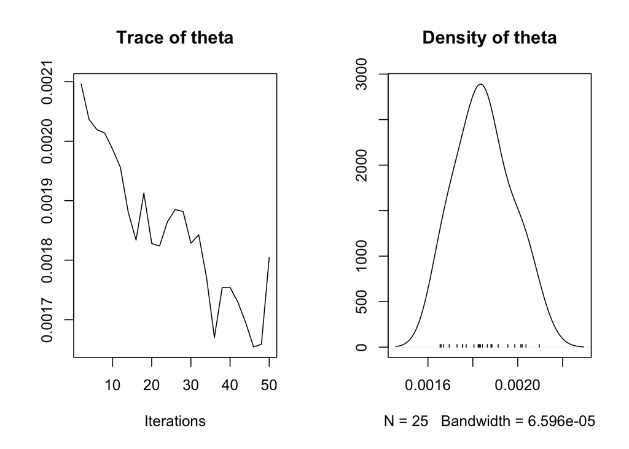

```r
varnames(example.MCMC) = "theta"
plot(example.MCMC)
```

Here’s a much better mcmc run with many more steps sampled and adequate burnin, demonstrating the “fuzzy caterpillar” shape:

```r
file.loc <- system.file("example.MCMC.M1.csv", package="ThetaMater")
mean(as.mcmc(read.csv(file = file.loc))) # close to the simulated value of 0.002
```

```
## [1] 0.00195588
```

```r
sd(as.mcmc(read.csv(file = file.loc)))
```

```
## [1] 9.646917e-05
```

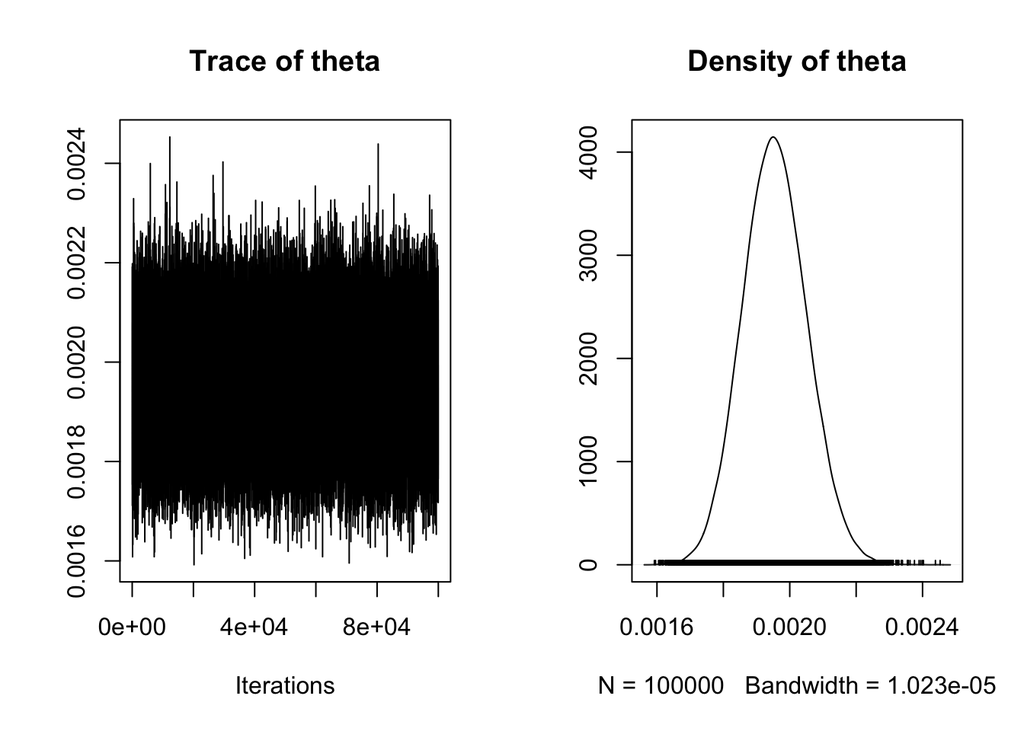

```r
plot(as.mcmc(read.csv(file = file.loc)))
```

Use the argument `ngens` to run the MCMC chain longer if your analysis has not yet converged to stationarity.

## Step 6: (Optional) Convert $\theta$ estimates into estimates of effective population size $N_e$

It is often desirable to convert estimates of $\theta$ into estimates of the true effective population size $N_e$. Giving an estimate of the mutation rate $\mu$, we can convert the posterior distriburion of $\theta$ into a posterior distribution of population $N_e$

$N_e = \theta/4\mu$

For example, let’s assume our given population evolved under a mutation rate $\mu$ of 2.2*10^-8 (similar to human estimates). We simply take the results from ThetaMater and divide the vector of $\theta$ by this mutation rate multiplied by factor of 4 (or 2 for haploid data).

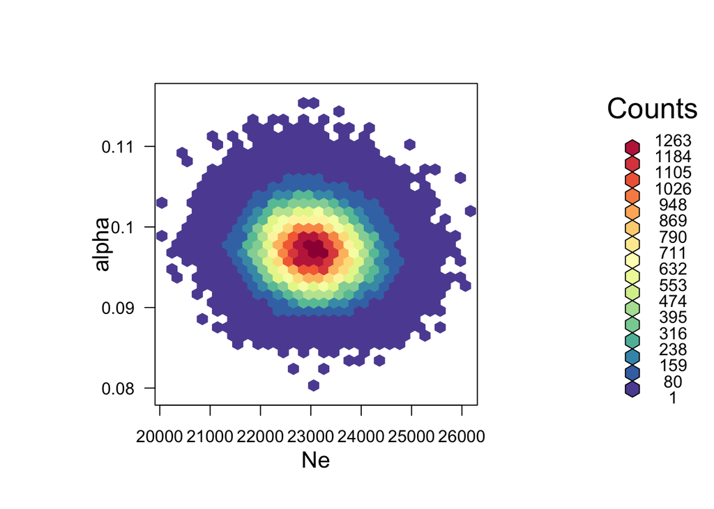

```r
# load the results from a ThetaMater analysis
data(example.MCMC.M3,package= "ThetaMater")
mutation.rate = 2.2*10^-8
example.MCMC.M3.Ne <- example.MCMC.M3
example.MCMC.M3.Ne[,1] = example.MCMC.M3.Ne[,1]/(mutation.rate*4)
h <- hexbin(example.MCMC.M3.Ne)
plot(h, colramp=rf, xlab = "Ne", ylab = "alpha")
```

## Step 7: (Optional) conduct posterior predictive simulation to remove loci with evidence of unlikely mutation counts (i.e., potential paralogs)

Finally, we can leverage the posterior distribution of $\theta$ that is estimated by ThetaMater to simulate posterior predictive simulated (PPS) distributions of mutation counts (k.vec) using the function ThetaMater.PPS. We can leaverage this PPS distribution filter out loci with unexpected mutation counts, such as incorrectly assembled paralogous loci, which will result in greater than expected numbers of single-locus ‘mutations’. The commands for using the function ThetaMater.PPS are as follows:

`ThetaMater.PPS(theta.MCMC, l.vec, n.vec)`  
* `l.vec`: vector of locus lengths  
* `n.vec`: vector of sample counts  
* `theta.MCMC`: Posterior distribution of theta inferred via ThetaMater

In this example, the PPS (white) and the observed (gray) distribution overlap considerably, and thus there is no need to filter out loci based on mutation counts alone

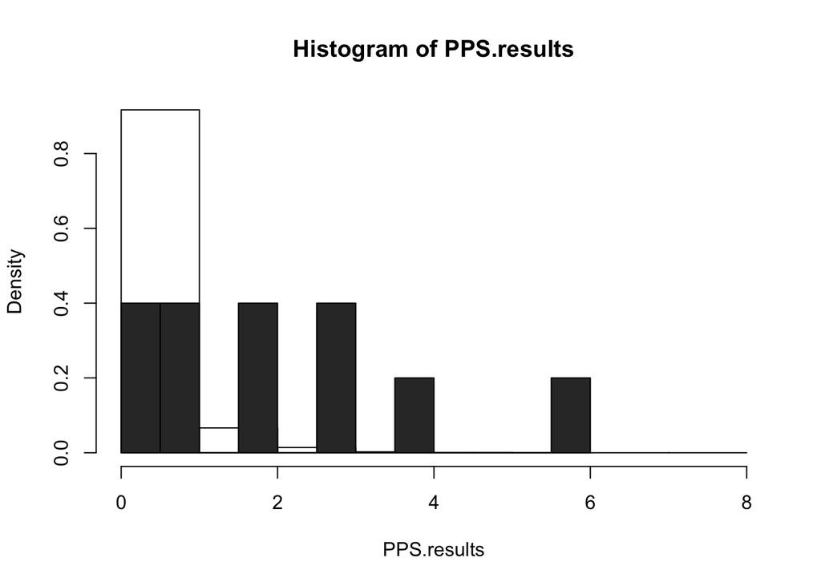

```r
data(example.dat,package= "ThetaMater")
file.loc <- system.file("example.MCMC.M1.csv", package="ThetaMater")
mcmc.results <- read.csv(file = file.loc) # close to the simulated value of
PPS.results <- ThetaMater.PPS(theta.MCMC = mcmc.results[,1], l.vec = example.dat$l.vec, n.vec = example.dat$n.vec)
hist(PPS.results, freq = F, breaks = 10)
hist(example.dat$k.vec, col="gray20",add=T, freq = F, breaks = 10)
```

Now, in this next sample we have a simulated dataset in which 4 paralogous loci (out of 1000) have been erronously placed into the same alignment, because they were assumed to be homologous. Using the code below, we will load the ‘example.SeqError.alles’ data into R and first estimate using this unfiltered dataset.

```r
# Let's look at the mutation count vector
data(example.SeqError.alles,package= "ThetaMater")
example.SeqError.alles$k.vec
```

```
##  [1]  0  1  2 23 28  3 31 38  4  5
```

Next, we estimated $\theta$ using ThetaMater.M1 on this unfiltered dataset:

```r
mcmc.seq.error <- ThetaMater.M1(k.vec= example.SeqError.alles$k.vec, l.vec = example.SeqError.alles$l.vec, n.vec = example.SeqError.alles$n.vec, c.vec = example.SeqError.alles$c.vec, ngens = 100000, burnin = 10000, thin = 100, theta.shape = 2, theta.scale = 0.001)
```

And here are the results:

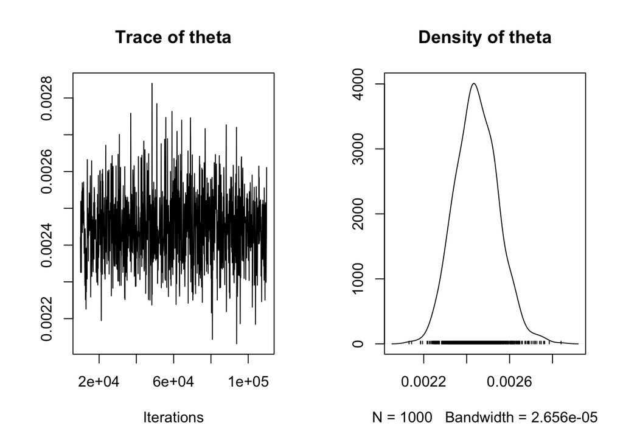

```r
data(example.MCMC.SequenceError, package = "ThetaMater")
varnames(example.MCMC.SequenceError) = "theta"
plot(as.mcmc(example.MCMC.SequenceError))
```

Now let’s conduct PPS using ThetaMater.PPS and overlay the distributions to see if we can identiy the 4 outlier loci:

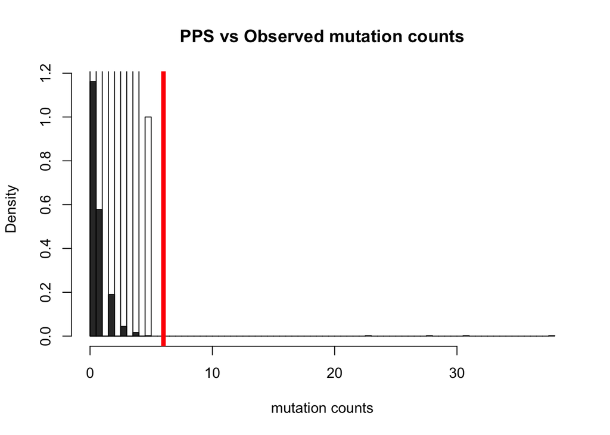

```r
# run PPS analysis using this command:
example.PPS.results <- ThetaMater.PPS(theta.MCMC = example.MCMC.SequenceError[,1], l.vec = example.SeqError.alles$l.vec, n.vec = example.SeqError.alles$n.vec)
hist(rep(example.SeqError.alles$k.vec, example.SeqError.alles$c.vec), col="gray20",add=F, freq = F, breaks = 100, main = "PPS vs Observed mutation counts", xlab = "mutation counts")
hist(example.PPS.results, freq = T, breaks = 10, add = T)
abline(v=6, col="red", lwd = 5)
```

Here the red line shows the maximum number of mutations observed in the PPS data. So, let’s remove the four extreme loci that are beyond this value and reestimate $\theta$ after filtering using this PPS distribution

```r
max(example.PPS.results)
```

```
## [1] 5
```

```r
example.Filtered <- FilterData.PPS(dataset = example.SeqError.alles, threshold = 6)
```

Now, let’s estimate $\theta$ after PPS filtering using the following commands:

```r
# Now let's estimate theta after PPS filtering
example.MCMC.PostFilter <- ThetaMater.M1(k.vec = example.Filtered$k.vec, l.vec = example.Filtered$l.vec, n.vec = example.Filtered$n.vec, c.vec = example.Filtered$c.vec, ngens = 100000, burnin = 10000, thin = 100, theta.shape = 2, theta.scale = 0.001)
```

And let’s load these results below:

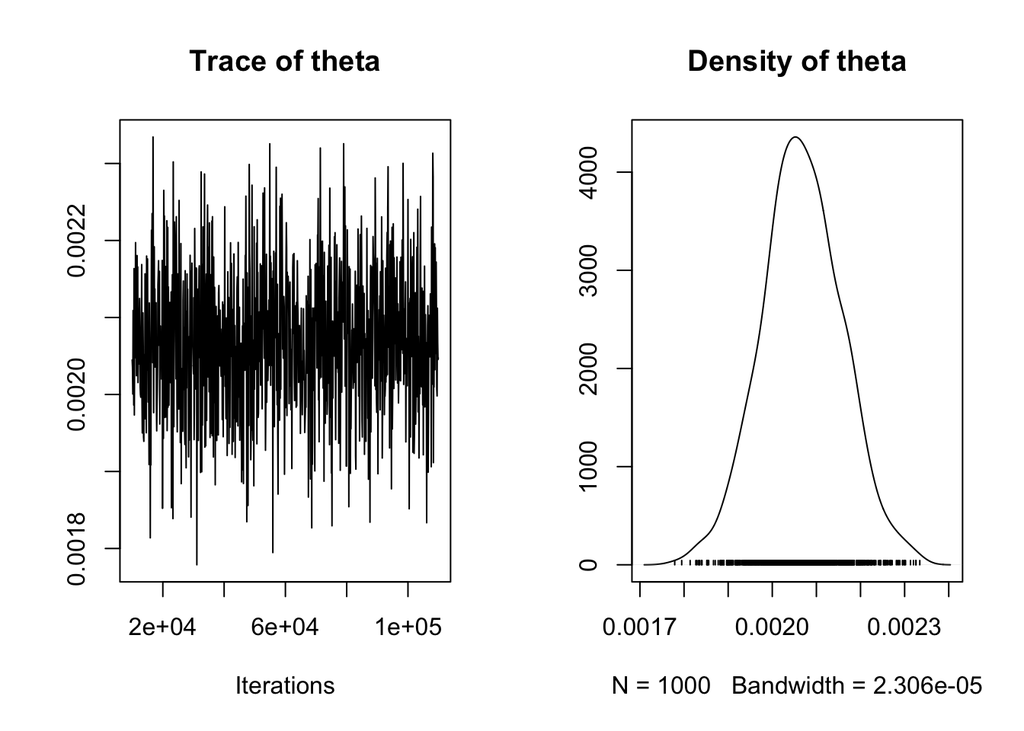

```r
data(example.MCMC.PostFilter, package = "ThetaMater")
varnames(example.MCMC.PostFilter) = "theta"
plot(as.mcmc(example.MCMC.PostFilter))
```